# White-Britt-ADA-homework-4

BA White

5/9/2020

install.packages(“rlang”)

```r
library(tidyverse)
```

```r
library(patchwork) # for plotting
library(scales) # for log y axis scale
library(collapse) # for `fmode()` to find mode
library(BBmisc) # for %nin%
library(devtools)
remotes::install_github("joachim-gassen/tidycovid19")
library(tidycovid19)
```

## Take downloaded dataset from covid19 package and tidy data for use

```r
merged <- download_merged_data(cached = TRUE)
```

[output not shown]

```r
merged <- merged %>%
  group_by(country, iso3c) %>%
  arrange(country, iso3c, date) %>%
  ## new code to replace NAs with zeros
  mutate(
    confirmed = ifelse(is.na(confirmed), 0, confirmed),
    deaths = ifelse(is.na(deaths), 0, deaths),
    recovered = ifelse(is.na(recovered), 0, recovered)
  ) %>%
  ## end of new code
  mutate(
    daily_confirmed = confirmed - lag(confirmed, n = 1),
    daily_deaths = deaths - lag(deaths, n = 1),
    daily_recovered = recovered - lag(recovered, n = 1)
  ) %>%
  mutate(
    daily_confirmed = replace_na(daily_confirmed, 0),
    daily_deaths = replace_na(daily_deaths, 0),
    daily_recovered = replace_na(daily_recovered, 0)
  ) %>%
  ungroup() %>%
  arrange(country, iso3c, date)

add_world1 <- merged %>%
  group_by(date) %>%
  arrange(date) %>%
  summarize(
    country = "World", iso3c = NA,
    confirmed = sum(confirmed, na.rm = TRUE),
    deaths = sum(deaths, na.rm = TRUE),
    recovered = sum(recovered, na.rm = TRUE),
    timestamp = fmode(timestamp)
  ) %>%
  mutate(
    daily_confirmed = confirmed - lag(confirmed, n = 1),
    daily_deaths = deaths - lag(deaths, n = 1),
    daily_recovered = recovered - lag(recovered, n = 1)
  ) %>%
  mutate(
    daily_confirmed = replace_na(daily_confirmed, 0),
    daily_deaths = replace_na(daily_deaths, 0),
    daily_recovered = replace_na(daily_recovered, 0)
  ) %>%
  ungroup() %>%
  arrange(country, iso3c, date)

add_world2 <- merged %>%
  group_by(country, iso3c) %>%
  summarize(
    population = fmode(population),
    land_area_skm = fmode(land_area_skm),
    timestamp = fmode(timestamp)
  ) %>%
  ungroup() %>%
  summarize(
    country = "World", iso3c = NA,
    population = sum(population, na.rm = TRUE),
    land_area_skm = sum(land_area_skm, na.rm = TRUE)
  ) %>%
  mutate(pop_density = population / land_area_skm)

add_world <- left_join(add_world1, add_world2, by = c("country", "iso3c"))
merged <- bind_rows(merged, add_world)

cv_data <- pivot_longer(merged,
  cols = c(
    "confirmed", "deaths", "recovered",
    "daily_confirmed", "daily_deaths", "daily_recovered"
  ),
  names_to = "variable", values_to = "cases"
) %>%
  arrange(country, variable, date) %>%
  rename(area = land_area_skm, density = pop_density) %>%
  mutate(rate = cases / population * 10^6) %>%
  ## new code to omit data before 2020-05-11
  filter(date < "2020-05-11")
## end of new code

cv_summary <- function(d, country_list = "World",
                       plot = TRUE, facet = "country",
                       status = c("confirmed", "deaths", "recovered")) {

  # based on `wes_palettes()` color schemes GrandBudapest1, IsleofDogs1,
  # IsleofDogs2 from the {wesanderson} package
  my_palette <- c(
    "#5B1A18", "#FD6467", "#F1BB7B", "#D67236",
    "#0F0D0E", "#9986A5", "#79402E", "#CCBA72", "#D9D0D3", "#8D8680",
    "#EAD3BF", "#AA9486", "#B6854D", "#39312F", "#1C1718"
  )

  if (facet == "country") {
    fill <- "variable"
    n <- length(unique(d$variable)) / 2
    # need only half of unique # of variable (3)
  }

  if (facet == "variable") {
    fill <- "country"
    n <- length(country_list)
    # need number of countries
  }

  if ("All" %in% country_list) {
    country_list <- unique(d$country)
    country_list <- setdiff(country_list, "World")
  }

  if ("World" %in% country_list) {
    d <- d %>% filter(country %in% country_list)

    totals <- d %>%
      group_by(variable) %>%
      summarize(
        country = "World",
        cases = max(cases),
        population = max(population),
        area = max(area),
        density = max(density),
        rate = max(rate, na.rm = TRUE),
        on = max(date)
      ) %>%
      select(country, variable, cases, population, area, density, rate, on) %>%
      arrange(variable) %>%
      ungroup()
  }

  if ("World" %nin% country_list) {
    d <- d %>% filter(country %in% country_list)
    totals <- d %>%
      group_by(country, variable) %>%
      summarize(
        cases = max(cases),
        population = max(population),
        area = max(area),
        density = max(density),
        rate = max(rate, na.rm = TRUE),
        on = max(date),
        gdp_capita = fmode(gdp_capita),
        income = fmode(income),
        life_expectancy = fmode(life_expectancy),
        max_sd = max(soc_dist),
        max_mr = max(mov_rest)
      ) %>%
      select(
        country, variable, cases, population, area, density, rate,
        gdp_capita, income, life_expectancy, max_sd, max_mr, on
      ) %>%
      arrange(country, variable) %>%
      ungroup()
  }

  if (plot == TRUE) {
    cc <- filter(d, variable %in% status)
    cum_cases_plot <- ggplot(
      data = cc,
      # use the tidy evaluation pronoun .data to slice the chosen fill
      # variable from the data frame
      aes(
        x = date, y = cases + 1, color = .data[[fill]],
        fill = .data[[fill]]
      )
    ) +
      geom_point(size = 0.5) +
      geom_line() +
      # use the tidy evaluation pronoun .data to slice the chosen facet_wrap
      # variable from the data frame
      facet_wrap(~ .data[[facet]], ncol = 5) +
      xlab("Date") +
      ylab("Log Cumulative Cases") +
      scale_y_log10(
        breaks = trans_breaks("log10", function(x) 10^x),
        labels = trans_format("log10", math_format(10^.x))
      ) +
      scale_color_manual(
        aesthetics = c("color", "fill"),
        name = NULL, values = my_palette
      )

    dc <- filter(d, variable %in% paste0("daily_", status))
    daily_cases_plot <- ggplot(
      data = dc,
      aes(
        x = date, y = cases, color = .data[[fill]],
        fill = .data[[fill]]
      )
    ) +
      geom_point(size = 0.5) +
      geom_line() +
      facet_wrap(~ .data[[facet]], ncol = 5) +
      xlab("Date") +
      ylab("Daily Cases") +
      scale_color_manual(
        aesthetics = c("color", "fill"),
        name = NULL, values = my_palette
      )
  }

  if (plot == TRUE) {
    return(list(
      totals = totals,
      cum_cases_plot = cum_cases_plot,
      daily_cases_plot = daily_cases_plot
    ))
  } else {
    return(list(totals = totals))
  }
}
```

## Challenge 1

# Use the dataset and function generated above to plot global data on confirmed coronavirus infections, deaths, and recoveries.

```r
cv_summary(cv_data)
```

```
## $totals
## # A tibble: 6 x 8
##   country variable          cases population      area density   rate on
##   <chr>   <chr>             <dbl>      <dbl>     <dbl>   <dbl>  <dbl> <date>
## 1 World   confirmed       4100108 7525907933    1.27e8    59.4 545.   2020-05-10
## 2 World   daily_confirmed   99113 7525907933    1.27e8    59.4  13.2  2020-05-10
## 3 World   daily_deaths       8856 7525907933    1.27e8    59.4   1.18 2020-05-10
## 4 World   daily_recovered   65439 7525907933    1.27e8    59.4   8.70 2020-05-10
## 5 World   deaths           282666 7525907933    1.27e8    59.4  37.6  2020-05-10
## 6 World   recovered       1407676 7525907933    1.27e8    59.4 187.   2020-05-10
##
## $cum_cases_plot
```

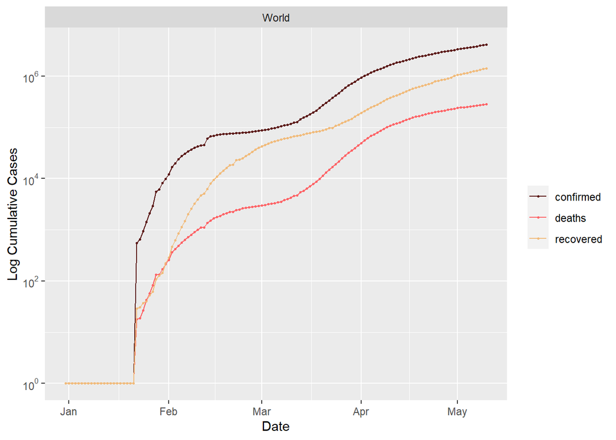

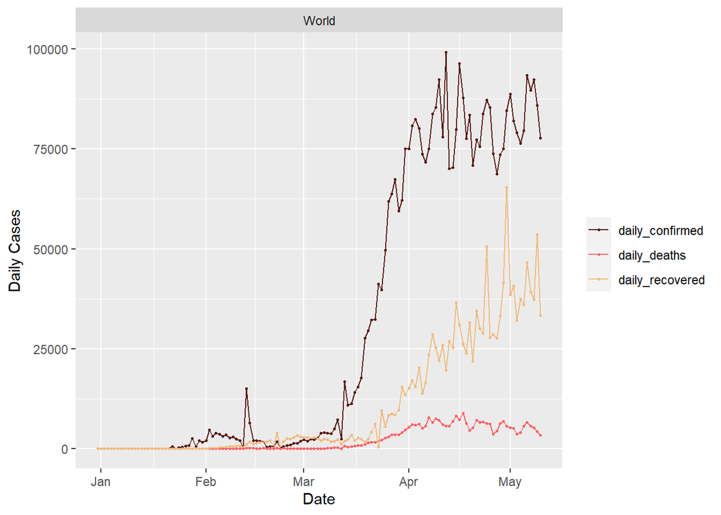

## Challenge 2

# Use the dataset and function generated above to plot data on confirmed coronavirus infections, deaths, and recoveries for the “Group of Seven” (G7) countries, which are the largest IMF-advanced economies in the world (i.e., the US, United Kingdom, Canada, France, Germany, Italy, and Japan) plus China, Russia, and Iran. Facet your plots first by “country” and then by “variable”.

```
## $totals
## # A tibble: 60 x 13
##    country variable cases population   area density    rate gdp_capita income
##    <chr>   <chr>    <dbl>      <dbl>  <dbl>   <dbl>   <dbl>      <dbl> <chr>
##  1 Canada  confirm~ 70091   37057765 9.09e6    4.08 1.89e+3     51392. High ~
##  2 Canada  daily_c~  2778   37057765 9.09e6    4.08 7.50e+1     51392. High ~
##  3 Canada  daily_d~   251   37057765 9.09e6    4.08 6.77e+0     51392. High ~
##  4 Canada  daily_r~  1385   37057765 9.09e6    4.08 3.74e+1     51392. High ~
##  5 Canada  deaths    4991   37057765 9.09e6    4.08 1.35e+2     51392. High ~
##  6 Canada  recover~ 32109   37057765 9.09e6    4.08 8.66e+2     51392. High ~
##  7 China   confirm~ 84010 1392730000 9.39e6  148.   6.03e+1      7753. Upper~
##  8 China   daily_c~ 15136 1392730000 9.39e6  148.   1.09e+1      7753. Upper~
##  9 China   daily_d~  1290 1392730000 9.39e6  148.   9.26e-1      7753. Upper~
## 10 China   daily_r~  3995 1392730000 9.39e6  148.   2.87e+0      7753. Upper~
## # ... with 50 more rows, and 4 more variables: life_expectancy <dbl>,
## #   max_sd <dbl>, max_mr <dbl>, on <date>
##
## $cum_cases_plot
```

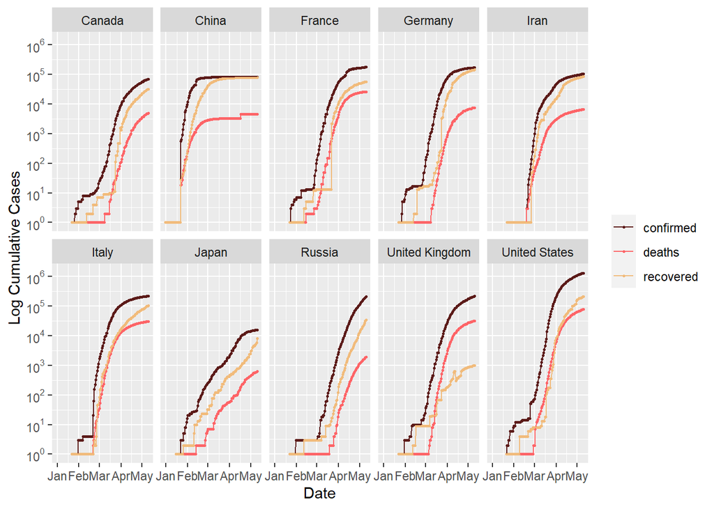

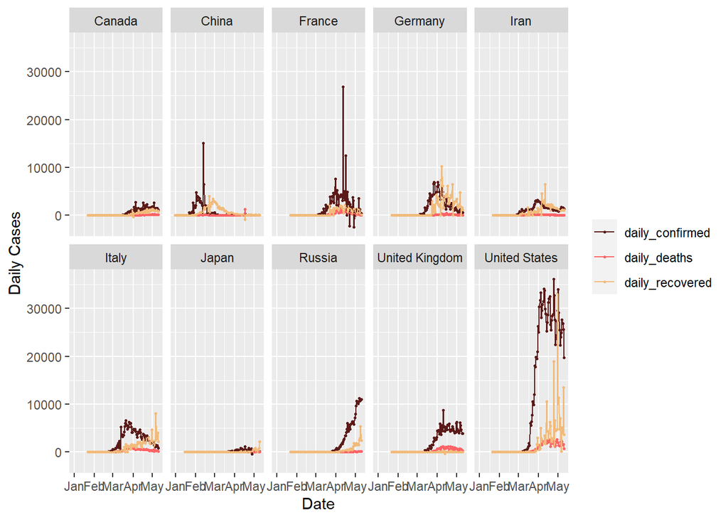

```
## $totals
## # A tibble: 60 x 13
##    country variable cases population   area density    rate gdp_capita income
##    <chr>   <chr>    <dbl>      <dbl>  <dbl>   <dbl>   <dbl>      <dbl> <chr>
##  1 Canada  confirm~ 70091   37057765 9.09e6    4.08 1.89e+3     51392. High ~
##  2 Canada  daily_c~  2778   37057765 9.09e6    4.08 7.50e+1     51392. High ~
##  3 Canada  daily_d~   251   37057765 9.09e6    4.08 6.77e+0     51392. High ~
##  4 Canada  daily_r~  1385   37057765 9.09e6    4.08 3.74e+1     51392. High ~
##  5 Canada  deaths    4991   37057765 9.09e6    4.08 1.35e+2     51392. High ~
##  6 Canada  recover~ 32109   37057765 9.09e6    4.08 8.66e+2     51392. High ~
##  7 China   confirm~ 84010 1392730000 9.39e6  148.   6.03e+1      7753. Upper~
##  8 China   daily_c~ 15136 1392730000 9.39e6  148.   1.09e+1      7753. Upper~
##  9 China   daily_d~  1290 1392730000 9.39e6  148.   9.26e-1      7753. Upper~
## 10 China   daily_r~  3995 1392730000 9.39e6  148.   2.87e+0      7753. Upper~
## # ... with 50 more rows, and 4 more variables: life_expectancy <dbl>,
## #   max_sd <dbl>, max_mr <dbl>, on <date>
##
## $cum_cases_plot
```

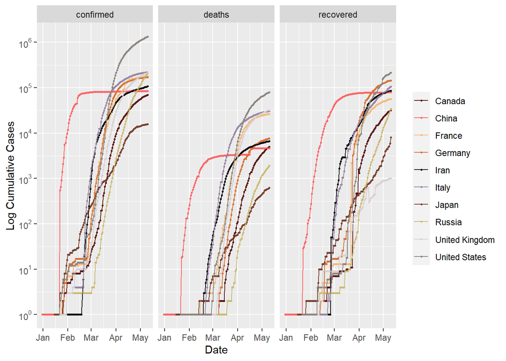

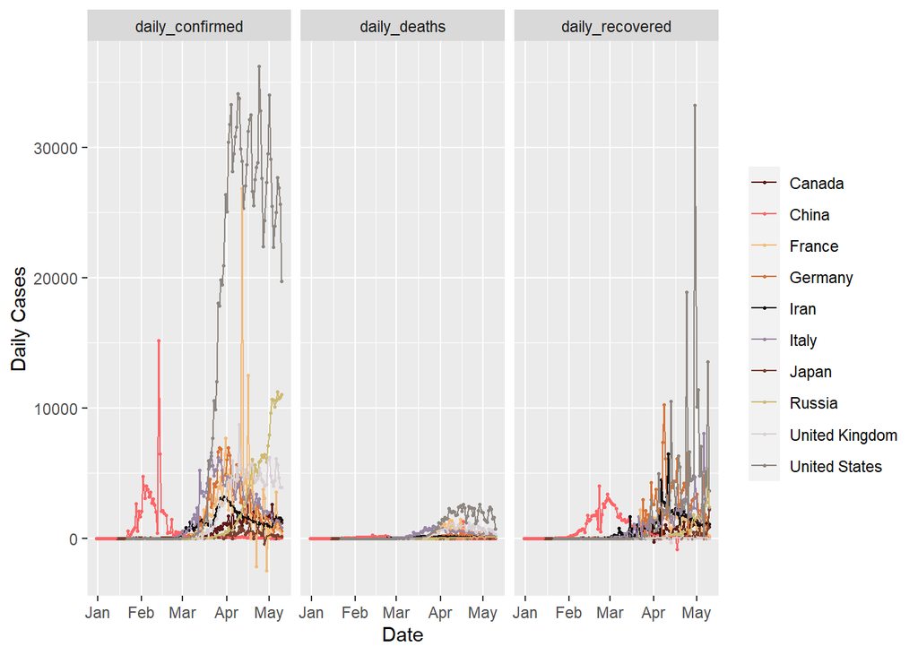

[output not shown]

```
## [1] "list"
```

```r
(All <- Allsum[[1]])
```

```
## # A tibble: 1,230 x 13
##    country variable cases population   area density    rate gdp_capita income
##    <chr>   <chr>    <dbl>      <dbl>  <dbl>   <dbl>   <dbl>      <dbl> <chr>
##  1 Afghan~ confirm~  4402   37172386 652860    56.9 118.          564. Low i~
##  2 Afghan~ daily_c~   369   37172386 652860    56.9   9.93        564. Low i~
##  3 Afghan~ daily_d~    13   37172386 652860    56.9   0.350       564. Low i~
##  4 Afghan~ daily_r~    56   37172386 652860    56.9   1.51        564. Low i~
##  5 Afghan~ deaths     120   37172386 652860    56.9   3.23        564. Low i~
##  6 Afghan~ recover~   558   37172386 652860    56.9  15.0         564. Low i~
##  7 Albania confirm~   868    2866376  27400   105.  303.         5079. Upper~
##  8 Albania daily_c~    34    2866376  27400   105.   11.9        5079. Upper~
##  9 Albania daily_d~     4    2866376  27400   105.    1.40       5079. Upper~
## 10 Albania daily_r~    31    2866376  27400   105.   10.8        5079. Upper~
## # ... with 1,220 more rows, and 4 more variables: life_expectancy <dbl>,
## #   max_sd <dbl>, max_mr <dbl>, on <date>
```

```r
class(All)
```

```
## [1] "tbl_df"     "tbl"        "data.frame"
```

```r
All <- as.data.frame(Allsum$totals)

# filter to countries over 1 million, storing this dataset as a tibble d.
d <- filter(All, population > 1000000)
d
```

```
##                      country        variable   cases population       area
## 1                Afghanistan       confirmed    4402   37172386   652860.0
## 2                Afghanistan daily_confirmed     369   37172386   652860.0
## 3                Afghanistan    daily_deaths      13   37172386   652860.0
## 4                Afghanistan daily_recovered      56   37172386   652860.0
## 5                Afghanistan          deaths     120   37172386   652860.0
## 6                Afghanistan       recovered     558   37172386   652860.0
## 7                    Albania       confirmed     868    2866376    27400.0
## 8                    Albania daily_confirmed      34    2866376    27400.0
## 9                    Albania    daily_deaths       4    2866376    27400.0
## 10                   Albania daily_recovered      31    2866376    27400.0
## 11                   Albania          deaths      31    2866376    27400.0
## 12                   Albania       recovered     650    2866376    27400.0
## 13                   Algeria       confirmed    5723   42228429  2381740.0
## 14                   Algeria daily_confirmed     199   42228429  2381740.0
```

[output cut: 2778 more lines]

```r
# How many countries does this tibble include?
length(unique(d$country))
```

```
## [1] 155
```

There are 155 countires with populations over 1,000,000 people.

## Challenge 4

# Filter d to generate two additional tibbles, overall and daily that include only data on the variables “confirmed” and “daily_confirmed” cases, respectively. Depending on the dataset, the case and rate variables either reflect the overall (i.e., across the pandemic) or maximum daily number of cases and number of cases recorded per million people in the population. Which 10 countries have experienced the highest over rate of confirmed cases? Which 10 countries have experienced the highest single-day rate of confirmed cases?

```r
# Overall
overall <- filter(d, variable == "confirmed")

# Daily
daily <- filter(d, variable == "daily_confirmed")

# countries with highest overall rate of cases
overall %>%
  arrange(desc(cases)) %>%
  head(n=10)
```

```
##           country  variable   cases population     area   density      rate
## 1   United States confirmed 1329260  326687501  9147420  35.76609 4068.9038
## 2           Spain confirmed  224350   46796540   499564  93.52906 4794.1579
## 3  United Kingdom confirmed  220449   66460344   241930 274.82739 3317.0006
## 4           Italy confirmed  219070   60421760   294140 205.45075 3625.6805
## 5          Russia confirmed  209688  144478050 16376870   8.82208 1451.3485
## 6          France confirmed  177094   66977107   547557 122.33840 2644.0975
## 7         Germany confirmed  171879   82905782   349360 237.37097 2073.1847
## 8          Brazil confirmed  162699  209469333  8358140  25.06172  776.7199
## 9          Turkey confirmed  138657   82319724   769630 106.96013 1684.3715
## 10           Iran confirmed  107603   81800269  1628760  50.22242 1315.4358
##    gdp_capita              income life_expectancy max_sd max_mr         on
## 1   54579.017         High income        78.53902      5     12 2020-05-10
## 2   32949.582         High income        83.33415      8      7 2020-05-10
## 3   43324.593         High income        81.35610     12      1 2020-05-10
## 4   35431.857         High income        82.94634     13     14 2020-05-10
## 5   11729.089 Upper middle income        72.65732      4     16 2020-05-10
## 6   43663.585         High income        82.52683      7      6 2020-05-10
## 7   47477.838         High income        80.99268      9     10 2020-05-10
## 8   11026.241 Upper middle income        75.67200      5     13 2020-05-10
## 9   15068.982 Upper middle income        77.43700      5     21 2020-05-10
## 10   6952.444 Upper middle income        76.47900      6      5 2020-05-10
```

```r
# countries with highest overall rate of rate
daily %>%
  arrange(desc(rate)) %>%
  head(n=10)
```

```
##      country        variable cases population   area    density     rate
## 1    Ecuador daily_confirmed 11536   17084357 248360   68.78868 675.2376
## 2      Qatar daily_confirmed  1311    2781677  11610  239.59320 471.2984
## 3     France daily_confirmed 26849   66977107 547557  122.33840 400.8683
## 4    Ireland daily_confirmed  1515    4867309  68890   70.45298 311.2603
## 5     Kuwait daily_confirmed  1065    4137309  17820  232.17222 257.4137
## 6  Singapore daily_confirmed  1426    5638676    709 7952.99842 252.8962
## 7    Belgium daily_confirmed  2454   11433256  30280  377.21493 214.6370
## 8    Bahrain daily_confirmed   330    1569439    778 2017.27370 210.2662
## 9      Spain daily_confirmed  9630   46796540 499564   93.52906 205.7844
## 10   Belarus daily_confirmed  1485    9483499 202988   46.72880 156.5878
##    gdp_capita              income life_expectancy max_sd max_mr         on
## 1    5185.091 Upper middle income        76.80000      3     11 2020-05-10
## 2   63260.558         High income        80.10000      4      5 2020-05-10
## 3   43663.585         High income        82.52683      7      6 2020-05-10
## 4   76880.808         High income        82.60732     18      8 2020-05-10
## 5   33112.130         High income        75.39800     13      9 2020-05-10
## 6   58247.873         High income        83.14634     35     19 2020-05-10
## 7   47166.484         High income        81.59512      8      4 2020-05-10
## 8   21438.410         High income        77.16300      6      7 2020-05-10
## 9   32949.582         High income        83.33415      8      7 2020-05-10
## 10   6744.499 Upper middle income        74.17561      2      7 2020-05-10
```

## Challenge 5

# Run a linear model to evaluate how the overall infection rate (rate) is related to the variables population density (density), population size (population), gross domestic product per capita (gdp_capita), and overall income level (income). In doing so, you should run exploratory visualizations to see whether or not the four numeric variables should be transformed.

```r
# linear model
overallrate <- lm(rate ~ density + population + gdp_capita + income, overall)
summary(overallrate)
```

```
##
## Call:
## lm(formula = rate ~ density + population + gdp_capita + income,
##     data = overall)
##
## Residuals:
##     Min      1Q  Median      3Q     Max
## -2551.0  -328.5   -64.2    48.3  5174.2
##
## Coefficients:
##                             Estimate Std. Error t value Pr(>|t|)
## (Intercept)                2.197e+02  2.777e+02   0.791   0.4303
## density                    2.257e-01  1.083e-01   2.085   0.0389 *
## population                -9.431e-08  4.467e-07  -0.211   0.8331
## gdp_capita                 4.186e-02  6.645e-03   6.300 3.41e-09 ***
## incomeLow income          -2.303e+02  3.216e+02  -0.716   0.4751
## incomeLower middle income -2.222e+02  3.026e+02  -0.734   0.4640
## incomeUpper middle income -3.936e+01  2.715e+02  -0.145   0.8850
## ---
## Signif. codes:  0 '***' 0.001 '**' 0.01 '*' 0.05 '.' 0.1 ' ' 1
##
## Residual standard error: 875.1 on 144 degrees of freedom
##   (4 observations deleted due to missingness)
## Multiple R-squared:  0.526,  Adjusted R-squared:  0.5062
## F-statistic: 26.63 on 6 and 144 DF,  p-value: < 2.2e-16
```

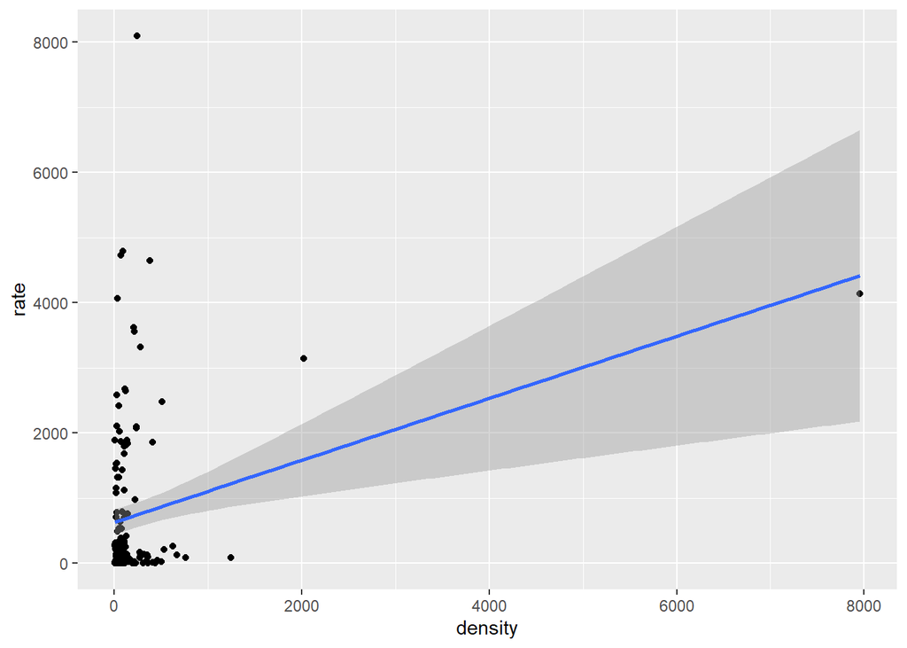

```r
# plot
logplotORD <- ggplot(overall, aes(density, rate)) +
  geom_point() +
  geom_smooth(method = "lm")
logplotORD
```

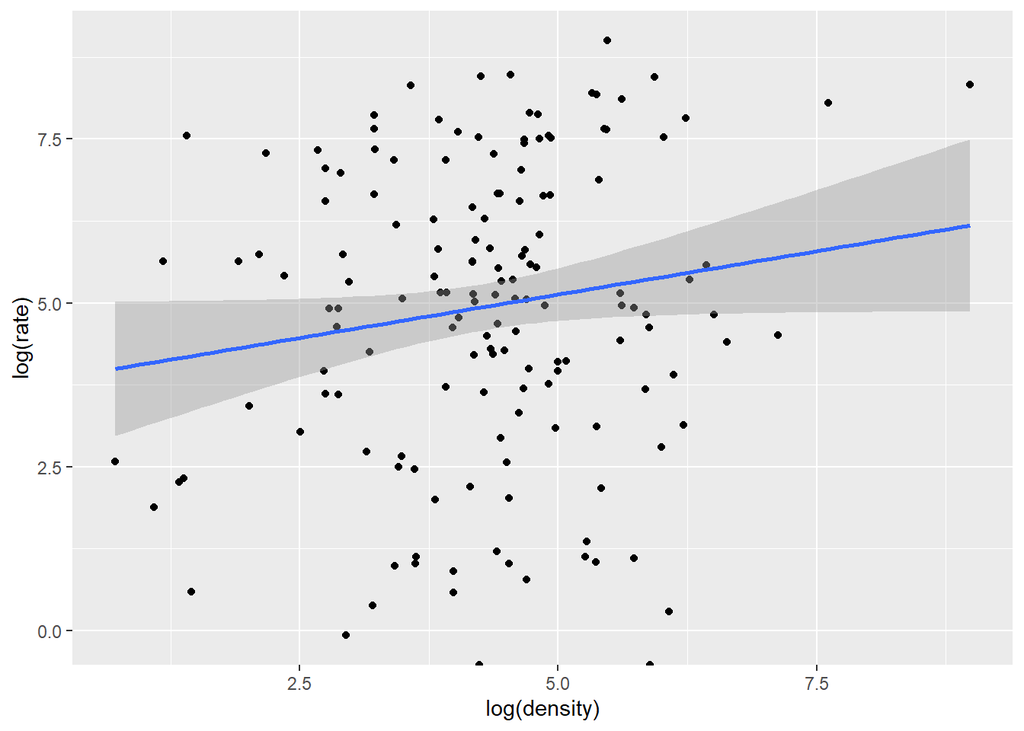

```r
logplotORD <- ggplot(overall, aes(log(density), log(rate))) +
  geom_point() +
  geom_smooth(method = "lm")
logplotORD
```

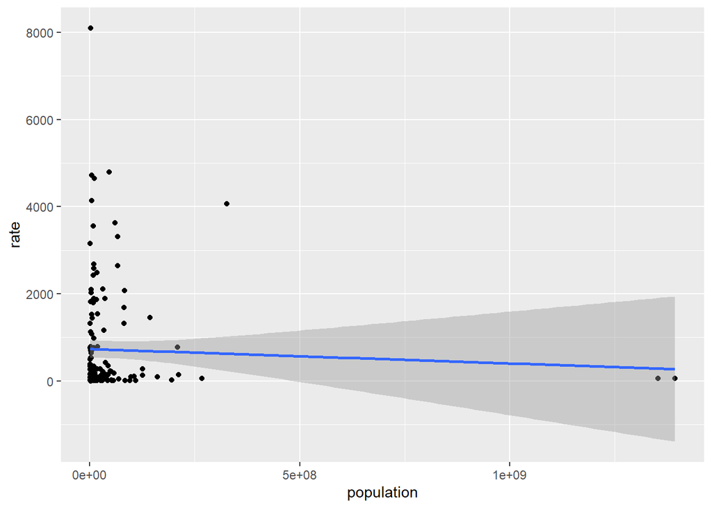

```r
plotORP <- ggplot(overall, aes(population, rate)) +
  geom_point() +
  geom_smooth(method = "lm")
plotORP
```

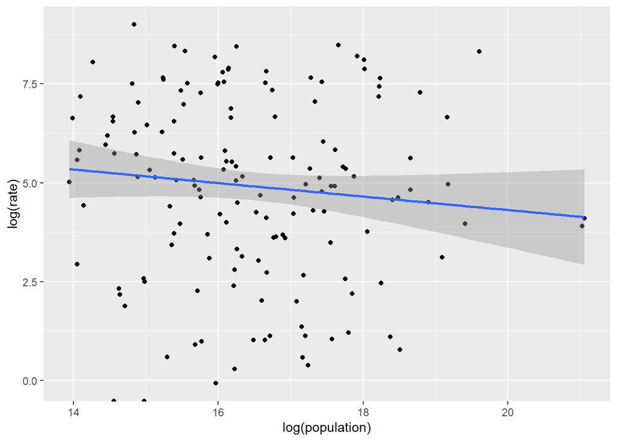

```r
logplotORP <- ggplot(overall, aes(log(population), log(rate))) +
  geom_point() +
  geom_smooth(method = "lm")
logplotORP
```

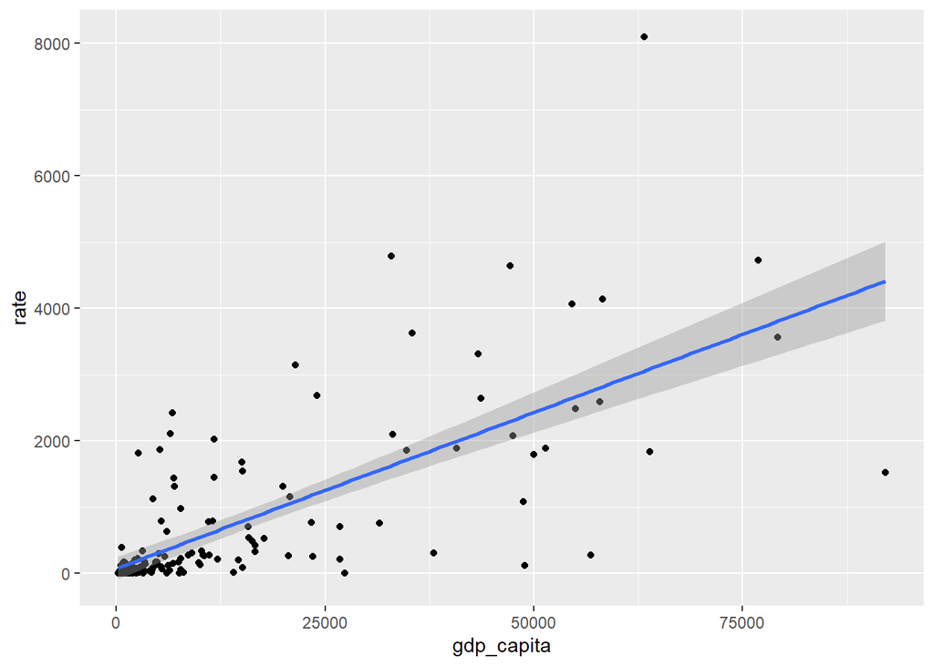

```r
plotORG <- ggplot(overall, aes(gdp_capita, rate)) +
  geom_point() +
  geom_smooth(method = "lm")
plotORG
```

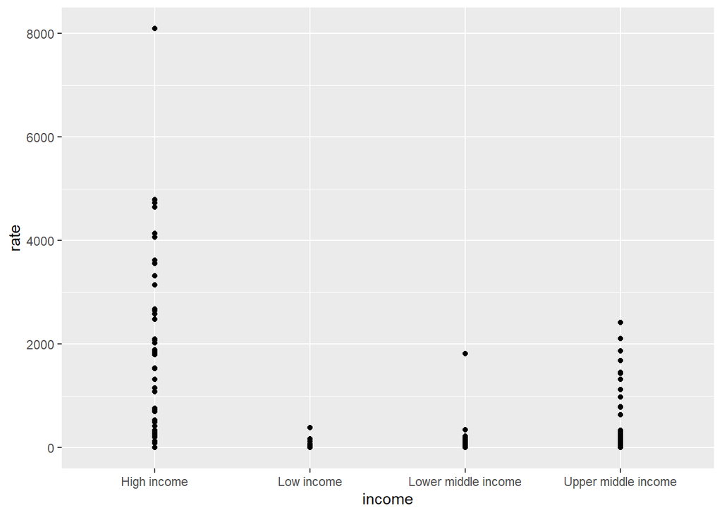

```r
plotORI <- ggplot(overall, aes(income, rate)) +
  geom_point() +
  geom_smooth(method = "lm")
plotORI
```

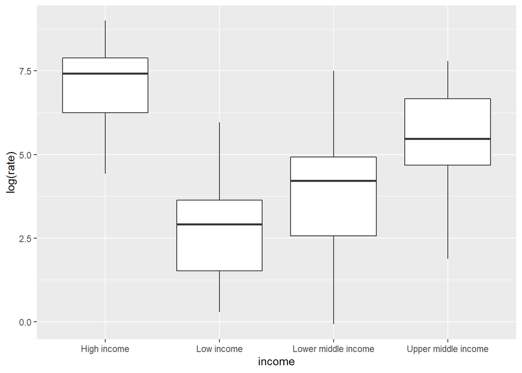

```r
logplotORI <- ggplot(overall, aes(income, log(rate))) +
  geom_boxplot()
logplotORI
```

```r
# this is categorical and doesn't appear to mean much in this form of visualization
```

# Based on the full model, what predictors variables have slopes significantly different from zero?

## Challenge 6

# Run stepwise selection using AIC to evaluate whether the full model or a nested, simpler model is preferred. What is the best model (based on AIC) of the possible ones involving these 4 predictors? What are the “pseudo- R2” values associated with the full and “best” models?

```r
# intercept only model
m0 <- lm(rate ~ 1, overall)
summary(m0)
```

```
##
## Call:
## lm(formula = rate ~ 1, data = overall)
##
## Residuals:
##    Min     1Q Median     3Q    Max
## -717.4 -688.2 -561.6   65.1 7378.4
##
## Coefficients:
##             Estimate Std. Error t value Pr(>|t|)
## (Intercept)   717.39      99.14   7.236 2.04e-11 ***
## ---
## Signif. codes:  0 '***' 0.001 '**' 0.01 '*' 0.05 '.' 0.1 ' ' 1
##
## Residual standard error: 1234 on 154 degrees of freedom
```

```r
add1(m0, scope = . ~ . + log(density) + log(population) + log(gdp_capita) + income, test = "F")
```

```
## Single term additions
##
## Model:
## rate ~ 1
##                 Df Sum of Sq       RSS    AIC F value    Pr(>F)
## <none>                       232644187 2153.4
## log(density)     1  10145433 222498753 2148.7  6.9764  0.009116 **
## log(population)  1    339869 232304318 2155.2  0.2238  0.636801
## log(gdp_capita)  1  89088200 143555987 2082.5 94.9490 < 2.2e-16 ***
## income           3  85381249 147262938 2090.4 29.1827 6.117e-15 ***
## ---
## Signif. codes:  0 '***' 0.001 '**' 0.01 '*' 0.05 '.' 0.1 ' ' 1
```

```r
# model without interaction
mwoi <- lm(rate ~ density + population + gdp_capita + income, overall)
summary(mwoi)
```

```
##
## Call:
## lm(formula = rate ~ density + population + gdp_capita + income,
##     data = overall)
##
## Residuals:
##     Min      1Q  Median      3Q     Max
## -2551.0  -328.5   -64.2    48.3  5174.2
##
## Coefficients:
##                             Estimate Std. Error t value Pr(>|t|)
## (Intercept)                2.197e+02  2.777e+02   0.791   0.4303
## density                    2.257e-01  1.083e-01   2.085   0.0389 *
## population                -9.431e-08  4.467e-07  -0.211   0.8331
## gdp_capita                 4.186e-02  6.645e-03   6.300 3.41e-09 ***
## incomeLow income          -2.303e+02  3.216e+02  -0.716   0.4751
## incomeLower middle income -2.222e+02  3.026e+02  -0.734   0.4640
## incomeUpper middle income -3.936e+01  2.715e+02  -0.145   0.8850
## ---
## Signif. codes:  0 '***' 0.001 '**' 0.01 '*' 0.05 '.' 0.1 ' ' 1
##
## Residual standard error: 875.1 on 144 degrees of freedom
##   (4 observations deleted due to missingness)
## Multiple R-squared:  0.526,  Adjusted R-squared:  0.5062
## F-statistic: 26.63 on 6 and 144 DF,  p-value: < 2.2e-16
```

```r
# full model
mwi <- lm(rate ~ density * population * gdp_capita * income, overall)
summary(mwi)
```

```
##
## Call:
## lm(formula = rate ~ density * population * gdp_capita * income,
##     data = overall)
##
## Residuals:
##     Min      1Q  Median      3Q     Max
## -2663.1  -277.1   -38.2    70.2  5184.6
##
## Coefficients:
##                                                           Estimate Std. Error
## (Intercept)                                             -6.583e+02  3.956e+02
## density                                                  1.804e+00  8.030e-01
## population                                               8.803e-05  2.877e-05
## gdp_capita                                               5.544e-02  8.379e-03
## incomeLow income                                         7.020e+02  1.296e+03
## incomeLower middle income                                7.402e+02  7.902e+02
## incomeUpper middle income                                1.677e+03  8.800e+02
## density:population                                      -1.730e-07  1.001e-07
## density:gdp_capita                                      -2.114e-05  1.529e-05
## population:gdp_capita                                   -1.479e-09  5.338e-10
## density:incomeLow income                                -2.023e+00  9.569e+00
## density:incomeLower middle income                       -2.476e+00  7.373e+00
## density:incomeUpper middle income                       -3.164e+00  4.549e+00
## population:incomeLow income                             -8.819e-05  5.900e-05
## population:incomeLower middle income                    -8.857e-05  3.029e-05
## population:incomeUpper middle income                    -8.776e-05  4.012e-05
## gdp_capita:incomeLow income                              1.157e-02  1.869e+00
## gdp_capita:incomeLower middle income                    -2.941e-02  2.659e-01
## gdp_capita:incomeUpper middle income                    -1.231e-01  9.391e-02
## density:population:gdp_capita                            1.929e-12  2.126e-12
## density:population:incomeLow income                      1.835e-07  7.558e-07
## density:population:incomeLower middle income             1.776e-07  1.170e-07
## density:population:incomeUpper middle income             2.115e-08  2.543e-07
## density:gdp_capita:incomeLow income                      6.309e-05  1.475e-02
## density:gdp_capita:incomeLower middle income             2.891e-04  2.804e-03
## density:gdp_capita:incomeUpper middle income             1.620e-04  5.138e-04
## population:gdp_capita:incomeLow income                  -3.891e-10  8.411e-08
## population:gdp_capita:incomeLower middle income          1.492e-09  4.039e-09
## population:gdp_capita:incomeUpper middle income          1.738e-09  2.676e-09
```

[output cut: 28 more lines]

```
## density:gdp_capita:incomeLower middle income              0.103  0.91805
## density:gdp_capita:incomeUpper middle income              0.315  0.75310
## population:gdp_capita:incomeLow income                   -0.005  0.99632
## population:gdp_capita:incomeLower middle income           0.369  0.71258
## population:gdp_capita:incomeUpper middle income           0.649  0.51729
## density:population:gdp_capita:incomeLow income           -0.011  0.99163
## density:population:gdp_capita:incomeLower middle income  -0.123  0.90248
## density:population:gdp_capita:incomeUpper middle income   0.616  0.53927
## ---
## Signif. codes:  0 '***' 0.001 '**' 0.01 '*' 0.05 '.' 0.1 ' ' 1
##
## Residual standard error: 884.2 on 119 degrees of freedom
##   (4 observations deleted due to missingness)
## Multiple R-squared:  0.6001, Adjusted R-squared:  0.4959
## F-statistic: 5.761 on 31 and 119 DF,  p-value: 1.375e-12
```

```r
# The mwi seems to fit better based on the R squared.

anova(mwi, mwoi, test = "F")
```

```
## Analysis of Variance Table
##
## Model 1: rate ~ density * population * gdp_capita * income
## Model 2: rate ~ density + population + gdp_capita + income
##   Res.Df       RSS  Df Sum of Sq      F Pr(>F)
## 1    119  93031053
## 2    144 110278271 -25 -17247218 0.8825  0.628
```

```r
# Here we see that the mwoi model increase the degrees of freedom by 25.

# AIC
library(MASS)
library(MuMIn)

AIC <- stepAIC(mwi, scope = . ~ ., direction = "both")
```

```
## Start:  AIC=2077.01
## rate ~ density * population * gdp_capita * income
##
##                                        Df Sum of Sq      RSS    AIC
## - density:population:gdp_capita:income  3    308969 93340022 2071.5
## <none>                                              93031053 2077.0
##
## Step:  AIC=2071.51
## rate ~ density + population + gdp_capita + income + density:population +
##     density:gdp_capita + population:gdp_capita + density:income +
##     population:income + gdp_capita:income + density:population:gdp_capita +
##     density:population:income + density:gdp_capita:income + population:gdp_capita:income
##
##                                        Df Sum of Sq      RSS    AIC
## - density:gdp_capita:income             3    505643 93845665 2066.3
## - population:gdp_capita:income          3   2533584 95873606 2069.6
## - density:population:income             3   2737506 96077528 2069.9
## - density:population:gdp_capita         1    715279 94055301 2070.7
## <none>                                              93340022 2071.5
## + density:population:gdp_capita:income  3    308969 93031053 2077.0
##
## Step:  AIC=2066.32
## rate ~ density + population + gdp_capita + income + density:population +
##     density:gdp_capita + population:gdp_capita + density:income +
##     population:income + gdp_capita:income + density:population:gdp_capita +
##     density:population:income + population:gdp_capita:income
##
##                                 Df Sum of Sq      RSS    AIC
## - population:gdp_capita:income   3   2137978 95983642 2063.7
## - density:population:income      3   2778319 96623984 2064.7
## - density:population:gdp_capita  1    773761 94619426 2065.6
## <none>                                       93845665 2066.3
## + density:gdp_capita:income      3    505643 93340022 2071.5
##
## Step:  AIC=2063.72
## rate ~ density + population + gdp_capita + income + density:population +
##     density:gdp_capita + population:gdp_capita + density:income +
##     population:income + gdp_capita:income + density:population:gdp_capita +
##     density:population:income
##
```

[output cut: 49 more lines]

```
## - income                         3    939756 105292663 2047.7
## <none>                                       104352908 2052.3
## + population:income              3   3739974 100612934 2052.8
## + density:income                 3   1821826 102531081 2055.7
## - density:population:gdp_capita  1   4573994 108926902 2056.8
## + gdp_capita:income              3    181000 104171908 2058.1
##
## Step:  AIC=2047.7
## rate ~ density + population + gdp_capita + density:population +
##     density:gdp_capita + population:gdp_capita + density:population:gdp_capita
##
##                                 Df Sum of Sq       RSS    AIC
## <none>                                       105292663 2047.7
## - density:population:gdp_capita  1   4446918 109739581 2051.9
## + income                         3    939756 104352908 2052.3
```

# Repeat this modeling process to evaluate what combination of explanatory variables best maximum daily infection rate. Are the important predictors the same? What additional or different variables are included?

```r
daily
```

```
##                      country        variable cases population       area
## 1                Afghanistan daily_confirmed   369   37172386   652860.0
## 2                    Albania daily_confirmed    34    2866376    27400.0
## 3                    Algeria daily_confirmed   199   42228429  2381740.0
## 4                     Angola daily_confirmed     7   30809762  1246700.0
## 5                  Argentina daily_confirmed   291   44494502  2736690.0
## 6                    Armenia daily_confirmed   163    2951776    28470.0
## 7                  Australia daily_confirmed   497   24982688  7692020.0
## 8                    Austria daily_confirmed  1321    8840521    82523.0
## 9                 Azerbaijan daily_confirmed   143    9939800    82670.0
## 10                   Bahrain daily_confirmed   330    1569439      778.0
## 11                Bangladesh daily_confirmed   887  161356039   130170.0
## 12                   Belarus daily_confirmed  1485    9483499   202988.0
## 13                   Belgium daily_confirmed  2454   11433256    30280.0
## 14                     Benin daily_confirmed   102   11485048   112760.0
```

[output cut: 453 more lines]

```r
d0 <- lm(rate ~ 1, daily)
summary(d0)
```

```
##
## Call:
## lm(formula = rate ~ 1, data = daily)
##
## Residuals:
##    Min     1Q Median     3Q    Max
## -45.08 -41.92 -33.81   4.99 630.15
##
## Coefficients:
##             Estimate Std. Error t value Pr(>|t|)
## (Intercept)   45.083      7.077   6.371 2.07e-09 ***
## ---
## Signif. codes:  0 '***' 0.001 '**' 0.01 '*' 0.05 '.' 0.1 ' ' 1
##
## Residual standard error: 88.1 on 154 degrees of freedom
```

```r
d1 <- lm(rate ~ density + population + gdp_capita + income, daily)
summary(d1)
```

```
##
## Call:
## lm(formula = rate ~ density + population + gdp_capita + income,
##     data = daily)
##
## Residuals:
##     Min      1Q  Median      3Q     Max
## -130.44  -31.80   -6.70    4.58  635.22
##
## Coefficients:
##                             Estimate Std. Error t value Pr(>|t|)
## (Intercept)                2.407e+01  2.453e+01   0.981  0.32820
## density                    1.684e-02  9.563e-03   1.761  0.08036 .
## population                -2.231e-08  3.946e-08  -0.565  0.57268
## gdp_capita                 1.943e-03  5.869e-04   3.311  0.00118 **
## incomeLow income          -2.023e+01  2.841e+01  -0.712  0.47745
## incomeLower middle income -2.022e+01  2.673e+01  -0.756  0.45063
## incomeUpper middle income  5.097e+00  2.398e+01   0.213  0.83198
## ---
## Signif. codes:  0 '***' 0.001 '**' 0.01 '*' 0.05 '.' 0.1 ' ' 1
##
## Residual standard error: 77.29 on 144 degrees of freedom
##   (4 observations deleted due to missingness)
## Multiple R-squared:  0.2761, Adjusted R-squared:  0.2459
## F-statistic: 9.152 on 6 and 144 DF,  p-value: 1.749e-08
```

```r
d2 <- lm(rate ~ density * population * gdp_capita * income, daily)
summary(d2)
```

```
##
## Call:
## lm(formula = rate ~ density * population * gdp_capita * income,
##     data = daily)
##
## Residuals:
##     Min      1Q  Median      3Q     Max
## -154.11  -23.25   -5.83    3.96  612.29
##
## Coefficients:
##                                                           Estimate Std. Error
## (Intercept)                                             -3.206e+01  3.653e+01
## density                                                  1.352e-01  7.413e-02
## population                                               5.004e-06  2.656e-06
## gdp_capita                                               3.005e-03  7.735e-04
## incomeLow income                                         4.555e+01  1.196e+02
## incomeLower middle income                                3.674e+01  7.295e+01
## incomeUpper middle income                                1.691e+02  8.125e+01
## density:population                                      -1.137e-08  9.244e-09
## density:gdp_capita                                      -1.817e-06  1.411e-06
## population:gdp_capita                                   -9.030e-11  4.928e-11
## density:incomeLow income                                -1.957e-01  8.834e-01
## density:incomeLower middle income                       -1.757e-01  6.807e-01
## density:incomeUpper middle income                       -4.990e-01  4.199e-01
## population:incomeLow income                             -5.227e-06  5.447e-06
## population:incomeLower middle income                    -5.013e-06  2.796e-06
## population:incomeUpper middle income                    -5.816e-06  3.704e-06
## gdp_capita:incomeLow income                             -4.304e-04  1.725e-01
## gdp_capita:incomeLower middle income                    -2.947e-04  2.455e-02
## gdp_capita:incomeUpper middle income                    -1.398e-02  8.670e-03
## density:population:gdp_capita                            1.529e-13  1.963e-13
## density:population:incomeLow income                      1.449e-08  6.978e-08
## density:population:incomeLower middle income             1.162e-08  1.080e-08
## density:population:incomeUpper middle income             1.093e-08  2.348e-08
## density:gdp_capita:incomeLow income                      3.854e-05  1.361e-03
## density:gdp_capita:incomeLower middle income             1.738e-05  2.589e-04
## density:gdp_capita:incomeUpper middle income             3.949e-05  4.743e-05
## population:gdp_capita:incomeLow income                   8.041e-12  7.765e-09
## population:gdp_capita:incomeLower middle income          7.669e-11  3.729e-10
## population:gdp_capita:incomeUpper middle income          1.802e-10  2.471e-10
```

[output cut: 28 more lines]

```
## density:gdp_capita:incomeLower middle income              0.067 0.946584
## density:gdp_capita:incomeUpper middle income              0.832 0.406796
## population:gdp_capita:incomeLow income                    0.001 0.999175
## population:gdp_capita:incomeLower middle income           0.206 0.837423
## population:gdp_capita:incomeUpper middle income           0.729 0.467207
## density:population:gdp_capita:incomeLow income           -0.032 0.974340
## density:population:gdp_capita:incomeLower middle income  -0.086 0.931919
## density:population:gdp_capita:incomeUpper middle income  -0.007 0.994489
## ---
## Signif. codes:  0 '***' 0.001 '**' 0.01 '*' 0.05 '.' 0.1 ' ' 1
##
## Residual standard error: 81.63 on 119 degrees of freedom
##   (4 observations deleted due to missingness)
## Multiple R-squared:  0.3328, Adjusted R-squared:  0.1589
## F-statistic: 1.914 on 31 and 119 DF,  p-value: 0.00693
```

```r
anova(d1, d2, test = "F")
```

```
## Analysis of Variance Table
##
## Model 1: rate ~ density + population + gdp_capita + income
## Model 2: rate ~ density * population * gdp_capita * income
##   Res.Df    RSS Df Sum of Sq      F Pr(>F)
## 1    144 860281
## 2    119 792916 25     67365 0.4044 0.9946
```

```r
r.squaredGLMM(d1)
```

```
##           R2m      R2c
## [1,] 0.267986 0.267986
```

```r
r.squaredGLMM(d2)
```

```
##            R2m       R2c
## [1,] 0.2834828 0.2834828
```

```r
AICd2 <- stepAIC(d2, scope = . ~ ., direction = "both")
```

```
## Start:  AIC=1357.5
## rate ~ density * population * gdp_capita * income
##
##                                        Df Sum of Sq    RSS    AIC
## - density:population:gdp_capita:income  3    56.027 792972 1351.5
## <none>                                              792916 1357.5
##
## Step:  AIC=1351.51
## rate ~ density + population + gdp_capita + income + density:population +
##     density:gdp_capita + population:gdp_capita + density:income +
##     population:income + gdp_capita:income + density:population:gdp_capita +
##     density:population:income + density:gdp_capita:income + population:gdp_capita:income
##
##                                        Df Sum of Sq    RSS    AIC
## - density:gdp_capita:income             3    6724.5 799697 1346.8
## - population:gdp_capita:income          3    8758.0 801730 1347.2
## - density:population:income             3   11263.7 804236 1347.6
## - density:population:gdp_capita         1    4020.1 796992 1350.3
## <none>                                              792972 1351.5
## + density:population:gdp_capita:income  3      56.0 792916 1357.5
##
## Step:  AIC=1346.78
## rate ~ density + population + gdp_capita + income + density:population +
##     density:gdp_capita + population:gdp_capita + density:income +
##     population:income + gdp_capita:income + density:population:gdp_capita +
##     density:population:income + population:gdp_capita:income
##
##                                 Df Sum of Sq    RSS    AIC
## - population:gdp_capita:income   3    5708.4 805405 1341.8
## - density:population:income      3   11451.3 811148 1342.9
## - density:population:gdp_capita  1    4487.5 804184 1345.6
## <none>                                       799697 1346.8
## + density:gdp_capita:income      3    6724.5 792972 1351.5
##
## Step:  AIC=1341.85
## rate ~ density + population + gdp_capita + income + density:population +
##     density:gdp_capita + population:gdp_capita + density:income +
##     population:income + gdp_capita:income + density:population:gdp_capita +
##     density:population:income
##
```

[output cut: 107 more lines]

```
## + population:gdp_capita  1       411  875408 1318.4
## + density:gdp_capita     1        18  875801 1318.5
## + income                 3     15538  860281 1319.8
## - gdp_capita             1    252555 1128374 1352.8
##
## Step:  AIC=1314.85
## rate ~ density + gdp_capita
##
##                      Df Sum of Sq     RSS    AIC
## <none>                             877774 1314.8
## - density             1     16639  894413 1315.7
## + population          1      1955  875819 1316.5
## + density:gdp_capita  1         3  877771 1316.8
## + income              3     15583  862191 1318.1
## - gdp_capita          1    255549 1133323 1351.4
```

## Challenge 7

# To the best model you determined in CHALLENGE 6 for predicting the maximum daily infection rate, add in the maximum social distancing (max_sd) and maximum movement restriction (max_mr) score per country. Do either of these additional variable improve the model significantly?

```r
d2adds <- lm(rate ~ density * population * gdp_capita * income * max_mr * max_sd, daily)
summary(d2adds)
```

```
##
## Call:
## lm(formula = rate ~ density * population * gdp_capita * income *
##     max_mr * max_sd, data = daily)
##
## Residuals:
##      Min       1Q   Median       3Q      Max
## -108.155   -4.726    0.000    4.671  200.282
##
## Coefficients: (5 not defined because of singularities)
##                                                                         Estimate
## (Intercept)                                                           -3.590e+02
## density                                                               -5.341e-01
## population                                                             5.739e-05
## gdp_capita                                                             8.915e-03
## incomeLow income                                                      -3.937e+02
## incomeLower middle income                                              7.750e+01
## incomeUpper middle income                                             -3.732e+03
## max_mr                                                                 5.188e+01
## max_sd                                                                 6.891e+01
## density:population                                                    -3.200e-07
## density:gdp_capita                                                     6.132e-05
## population:gdp_capita                                                 -1.507e-09
## density:incomeLow income                                              -1.400e+00
## density:incomeLower middle income                                      5.720e-01
## density:incomeUpper middle income                                      4.923e+01
## population:incomeLow income                                           -2.455e-05
## population:incomeLower middle income                                  -3.877e-05
## population:incomeUpper middle income                                   1.146e-04
## gdp_capita:incomeLow income                                            8.463e-01
## gdp_capita:incomeLower middle income                                   1.123e-01
## gdp_capita:incomeUpper middle income                                   5.655e-01
## density:max_mr                                                        -2.100e-01
## population:max_mr                                                     -6.365e-06
## gdp_capita:max_mr                                                     -1.021e-03
## incomeLow income:max_mr                                                5.514e+01
## incomeLower middle income:max_mr                                      -2.305e+01
## incomeUpper middle income:max_mr                                       3.872e+02
## density:max_sd                                                         1.139e-01
## population:max_sd                                                     -9.998e-06
```

[output cut: 607 more lines]

```
## density:gdp_capita:incomeLower middle income:max_mr:max_sd
## density:gdp_capita:incomeUpper middle income:max_mr:max_sd            *
## population:gdp_capita:incomeLow income:max_mr:max_sd
## population:gdp_capita:incomeLower middle income:max_mr:max_sd
## population:gdp_capita:incomeUpper middle income:max_mr:max_sd
## density:population:gdp_capita:incomeLow income:max_mr:max_sd
## density:population:gdp_capita:incomeLower middle income:max_mr:max_sd
## density:population:gdp_capita:incomeUpper middle income:max_mr:max_sd **
## ---
## Signif. codes:  0 '***' 0.001 '**' 0.01 '*' 0.05 '.' 0.1 ' ' 1
##
## Residual standard error: 84.31 on 27 degrees of freedom
##   (5 observations deleted due to missingness)
## Multiple R-squared:  0.8382, Adjusted R-squared:  0.1072
## F-statistic: 1.147 on 122 and 27 DF,  p-value: 0.3511
```

```r
AICd2adds <- stepAIC(d2adds, scope = . ~ ., direction = "both")
```

```
## Start:  AIC=1319.11
## rate ~ density * population * gdp_capita * income * max_mr *
##     max_sd
##
##                                                      Df Sum of Sq    RSS    AIC
## <none>                                                            191900 1319.1
## - density:population:gdp_capita:income:max_mr:max_sd  2     78658 270557 1366.6
```

```r
r.squaredGLMM(d2)
```

```
##            R2m       R2c
## [1,] 0.2834828 0.2834828
```

```r
r.squaredGLMM(d2adds)
```

```
##            R2m       R2c
## [1,] 0.4842448 0.4842448
```

## Challenge 8

# Finally, let’s go back to the original cv_data tibble… we will now run a set of “mixed effects” model! First, filter the tibble to include only data for countries with a population of > 1 million and to include only those rows of data for daily_confirmed cases (i.e., variable == “daily_confirmed”). Also filter the dataset to only include rows where rate > 0 (i.e., where there was at least 1 new recorded cases on a day). Then, run a set of linear mixed effects models that include the fixed and random effects indicated in the table below. Start with the full model (4 fixed effects and 2 random effects) as m1 and then run nested models with different subsets of fixed predictors, but always keeping country and date as random effects. Use the lmer() function from the {lme4} package with the argument REML=FALSE specified, as discussed in Module 24. Then, construct an AIC table for the full set of models that you run, and be sure to run a null model with ONLY random effects. What is the best model of the complete set that you ran? What is the “pseudo- R2” value associated with that model?

```r
# filter OG tibble pop & rate > 0
OG_tib_filtered <- cv_data %>%
  filter(population > 1000000 & variable == "daily_confirmed" & rate > 0)

library(lme4)
# run mixed linear models
# intercept model
interm <- lmer(data = OG_tib_filtered, log(rate) ~ (1 | country) + (1 | date), REML=FALSE)

# full model
m1 <- lmer(data = OG_tib_filtered, log(rate) ~ log(density) + log(gdp_capita) + soc_dist + mov_rest +
  (1 | country) + (1 | date), REML=FALSE)

# another model
m2 <- m2 <- lmer(data = OG_tib_filtered, log(rate) ~ log(density) + log(gdp_capita) + soc_dist +
  (1 | country) + (1 | date), REML=FALSE)

# another model
m3 <- lmer(data = OG_tib_filtered, log(rate) ~ log(density) + log(gdp_capita) + mov_rest +
  (1 | country) + (1 | date), REML=FALSE)

# another model
m4 <- lmer(data = OG_tib_filtered, log(rate) ~ log(density) + log(gdp_capita) +
  (1 | country) + (1 | date), REML=FALSE)

# another model
m5 <- lmer(data = OG_tib_filtered, log(rate) ~ log(density) + soc_dist + mov_rest +
  (1 | country) + (1 | date), REML=FALSE)

# another model
m6 <- lmer(data = OG_tib_filtered, log(rate) ~ log(gdp_capita) + soc_dist + mov_rest +
  (1 | country) + (1 | date), REML=FALSE)

# another model
m7 <- lmer(data = OG_tib_filtered, log(rate) ~ log(gdp_capita) + soc_dist +
  (1 | country) + (1 | date), REML=FALSE)

# another model
m8 <- lmer(data = OG_tib_filtered, log(rate) ~ log(gdp_capita) + mov_rest +
  (1 | country) + (1 | date), REML=FALSE)

# AIC Table
library(AICcmodavg)
AICtable <- aictab(list(interm, m1, m2, m3, m4, m5, m6, m7, m8),
  modnames = c("interm", "m1", "m2", "m3", "m4", "m5", "m6", "m7", "m8"))

AICtable
```

```
##
## Model selection based on AICc:
##
##        K     AICc Delta_AICc AICcWt Cum.Wt        LL
## m1     8 25476.01       0.00      1      1 -12729.99
## m2     7 25548.30      72.29      0      1 -12767.14
## m6     7 25671.66     195.65      0      1 -12828.82
## m7     6 25741.38     265.38      0      1 -12864.69
## m5     7 25761.34     285.33      0      1 -12873.66
## m3     7 25785.66     309.65      0      1 -12885.82
## m4     6 25847.77     371.76      0      1 -12917.88
## m8     6 25993.00     516.99      0      1 -12990.49
## interm 4 26634.61    1158.60      0      1 -13313.30
```

```r
# Model 1 seems to be the best model

# R Squared
r.squaredGLMM(interm)
```

```
##      R2m       R2c
## [1,]   0 0.8249299
```

```r
r.squaredGLMM(m1)
```

```
##            R2m       R2c
## [1,] 0.2909455 0.8241297
```

```r
# The pseudo R didn't really change
```